# EDA_XP

Olivier Leroy

12 août 2019

# 1 Présentation du test

## 1.1 Zone de test

### 1.1.1 Localisation et limite de la zone de test

La zone du test (figure : 1.1) a eu lieu à Saint-Etienne dans le quartier Carnot-Manufacture d’armes. Elle est délimitée au nord par le campus de Manufacture de l’Université Jean Monet, à l’est par le boulevard Thiers, à l’ouest par la ligne de tramway et au sud par le boulevard Jules Janin. Ce sont des axes simples à reconnaître même pour quelqu’un de non familier de la zone.

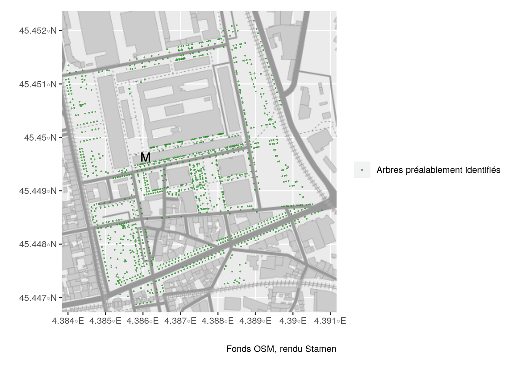

Figure 1.1: Carte de présentation de la zone de test

L’endroit est entièrement couverte par un wifi et dispose de prises de chargement de portables en accès libre.

### 1.1.2 Arbres de la zone de test

Cette zone représente 24.22 ha, comprend 1133 arbres soit 46.78 arbres par hectare. Les arbres peuvent y être présents en alignement, en petits bosquets et dans des parcs.

Il y a entre 41 et 42 genres d’arbres (en fonction d’où on range les macromeles). Prés de 50% des arbres se retrouvent être soit des *Platanus* (une seule espèce) soit des *Prunus* (6 espèces). 62 espèces se répartissent dans ces genres.

Les arbres sont en moyennes à 5,53 m les uns des autres, avec une médiane de 5,35 m et pour 90% des arbres cette distance est comprise entre 1,75 et 9,73 m. (note olivier, au regard des activités il serait bon de regarder la distance au prochain genre différents, pe aussi quantifier un peu plus l’hétérogeneité)

## 1.2 Les 5 activités

Il y a eu 5 activités de proposés :

- 1 : “Faites 5 relevés”
- 2 : “Faites 3 relevés de genres différents”
- 3 : “Vérifiez 3 relevés d’un autre utilisateur (cercle vert clignotant)”
- 4 : “Identifiez 3 relevés d’expert (cercle bleu clignotant)”
- 5 : “Faites un maximum de relevé en un temps limite”

Il était aussi possible de faire un relevé hors activité (6). Les activités 1 et 2 demandent un nombre précis de relevés pour être validés (respectivement 5 et 3). Les participants pouvaient être répartis en deux groupes. Le premier n’avait que ces activités alors que le second avait en plus un système de point gratifiant l’ajout d’infomations (mettre le tableau ?) et de trophés (idem?)

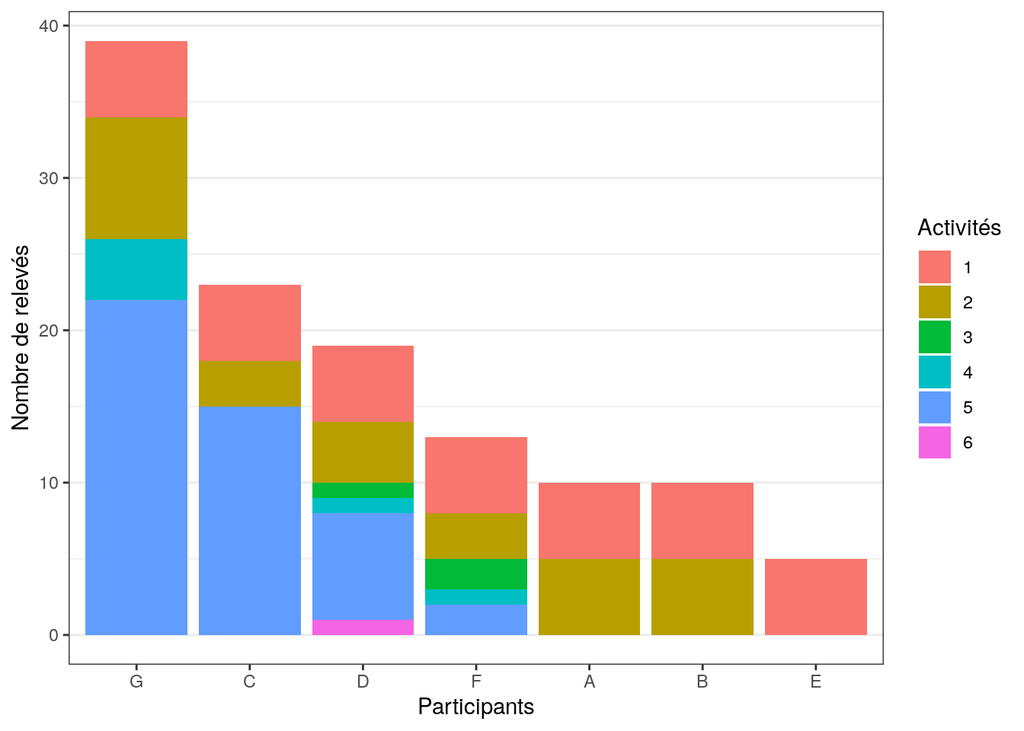

Figure 1.2: Nombre de reĺevés par participants en fonction des activités

## 1.3 Travail sur les données

### 1.3.2 Validation genre et espèce

#### 1.3.2.1 Méthode de validation

La vérification des genres et espèces c’est fait dans un premier temps à l’aide d’un SIG “bureau” en comparant le relevé de l’utilisateur à ce que nous connaissions via la base de données. C’est difficile de l’automatiser car l’arbre le plus proche n’est pas obligatoirement celui relevé. Dans le cas de doute, relevé loin d’un arbre pouvant correspondre ou une erreur peu probable (espèce vraiment différente) nous sommes allés directement sur le terrain pour vérifier.

Dans ces cas la photo fût aussi utilisée, via `albiziapp explorer` et fût d’une aide précieuse.

Lors de la première expérience la validité de l’information botanique a été codée comme ceci :

`bota` est le champs correspondant à l’exactitude de l’information botanique. Il peut prendre les valeurs de :

- 0 : une erreur d’identification
- 1 : le genre est présent et bon
- 2 : genre et nom commun présents et bons
- 3 : genre / non commun / espèce de présents
- 4 : genre bon mais reste mauvais (redondant avec 1, la différence est que 1 ne devait qu’avoir le genre)
- 5 : Nom commun de bon
- 6 : genre et non latin de bon

J’avais fait une seule variable car j’avais l’impression de forte corrélation, mais au final c’est plus simple de faire plusieurs variables (tout en gardant en tête une éventuelle corrélation).

Pour simplifier un recodage par info à été fait :

- `commun_bon` : 0 = faux (`bota` = 0, 1, 4, 6) et 1 bon (`bota` = 2, 3 ou 5) et NA si pas d’info (ne devrait-on pas mettre 0 ?)
- `genre_bon` : 0 = faux et (`bota` = 0, 5) 1 bon (`bota` = 1, 2, 3, 4 et 6) et NA si pas d’info
- `espece_bon` : 0 = faux et 1 bon (`bota` = 3) et NA si pas d’info

C’est cette forme de codage qui a été gardé par la suite.

#### 1.3.2.2 Difficultés rencontrées et choix dans les cas limites

Il y a plusieurs cas pouvant poser problème sur ce que l’on entend comme un arbre “validé”. On a d’abord le cas d’arbustes qui peuvent être inclus dans des haies ou isolés comme des troènes (cf. figure : 1.3) ou des rosiers. Il y a aussi le cas de jeunes arbres ou arbustes qui peuvent devenir des arbres de plus grandes statures mais qui sont pour le moment de petites tailles (cf. figure : 1.4).

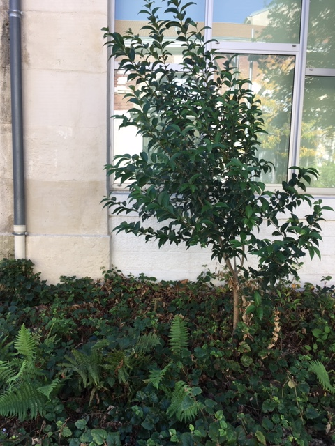

Figure 1.3: Petit troène absent de la base

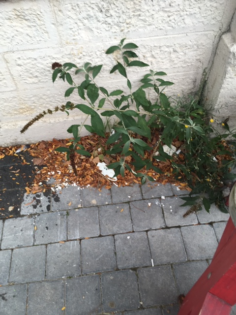

Figure 1.4: Jeune buddleja absent de la base

Le système via genre/nom commun/espèce permet d’éviter de mettre juste “faux” pour les platanes. Il faudra cependant bien faire attention dans l’analyse à des effets d’espèces (des espèces plus difficiles, reproduit-on tout le temps la même erreur : cas d’une essence mal identifiée plusieurs fois)

#### 1.3.2.3 Arbres présents sur le terrain et absent de la base

`Ajout` : correspond à un arbre non présent dans la base, que les participants ont trouvé et qui existe bien (cf. figure : 1.5). Les arbustes mentionnées plus haut sont aussi souvent dans cette catégorie.

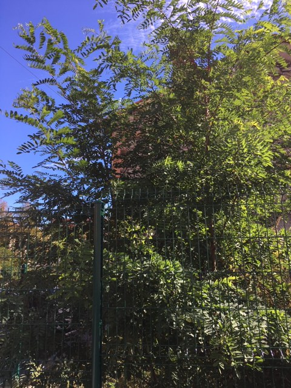

Figure 1.5: Robinier faux acacia dans une friche, absent de la base

# 2 Premiers résultats

## 2.1 Synthèse rapide

### 2.1.1 Expèrience du 29 juin

Le tableau 2.1 indique pour chaque participant le nombre de relevés effectués (`nb_releve`), le nombre de relevés avec le nom commun, le genre et l’espèce de renseignés (`commun_bon`, `genre_bon` et `espece_bon`) et le nombre de ces relevés qui sont bon pour chaque catégorie botanique (ex : `genre_bon` pour le nombre de relevés ou le genre est bon).

|  | Participant | nb_releve | nb_commun | commun_bon | nb_genre | genre_bon | nb_espece | espece_bon |
| --- | --- | --- | --- | --- | --- | --- | --- | --- |
| 1 | G | 39 | 1 | 1 | 6 | 5 | 5 | 1 |
| 2 | C | 23 | 18 | 12 | 23 | 18 | 14 | 10 |
| 3 | D | 19 | 16 | 9 | 18 | 15 | 18 | 9 |
| 4 | F | 13 | 10 | 2 | 13 | 10 | 13 | 2 |
| 5 | A | 10 | 5 | 1 | 5 | 3 | 0 | 0 |
| 6 | B | 10 | 8 | 5 | 3 | 3 | 0 | 0 |
| 7 | E | 5 | 4 | 2 | 5 | 5 | 5 | 2 |

Table 2.1: caption Informations botaniques par participants

La distance moyenne entre deux relevés d’arbres les plus proches est de 11,48 m et sa médiane est de 10,16. 90% de ces distances sont comprises entres 2,52 et 19,93 m.